# Recursion

Xu Liu

# 1 Quick sort

- It takes time $O(nlog_2n)$ and space $log_2n$.

## 1.1 Key point

- Select randomly a number x, say x=s[i]. In the first step, you may set x=s[0];
  - Find a position for x, which satisfies that the numbers before x are not greater than x, and the numbers after x are not smaller than x.
  - Then split the sequence into two parts from x
  - Apply the same way in the two parts again
- Iterate above steps until each segment only has one element

## 1.2 C codes

```c
//run on VS 2010
#include <stdlib.h>
#define N 10
void QSort_int(int *s, int l, int r){
    int i, j, x;
    if (l < r){
        i = l; j = r; x = s[i];
        while (i < j){
            while(i < j && s[j] > x)
              j--;
                  if(i < j)
                    s[i++] = s[j];
            while(i < j && s[i] < x)
              i++;
                  if(i < j)
                    s[j--] = s[i];

                  printf("step=%d, x=%d\n",++step, x);
                  for (int ii = 0; ii < N; ii++)
                    printf("%d ",s[ii]);
                  printf("\n");
        }
        s[i] = x;

        printf("i=%d, x=%d\n",i,x);
        for (int ii = 0; ii < N; ii++)
          printf("%d ",s[ii]);
        printf("\n");

        QSort_int(s, l, i-1);
        QSort_int(s, i+1, r);
    }
}

int main(){
    int i,j;
    int b[100], c[100];
    srand(1);
    for (i = 0; i < 100; i++) b[i] = rand() % 100;
    srand(1000);
    for (i = 0; i < 100; i++) c[i] = rand() % 100;

    printf("b[i]=");
    for (i = 0; i < N; i++)
      printf("%d\t",b[i]);printf("\n");

    QSort_int(b,0,N-1);

    printf("b[i]=");
    for (i = 0; i < N; i++)
      printf("%d\t",b[i]);printf("\n");

    fflush(stdin);
    getchar();
    return 0;
}
```

# 2 Find an element

- It takes time $log_2n$.

## 2.1 Key point

- Let input value is “x”
- Compare x with the middle element of the increasing sequence “a”
  - Search by the same way in the first segment if x<=a[middle]
  - Search by the same way in the second segment if x>a[middle]
- Iterate above steps until
  - you find x, output the position
  - or the segment only has one element, output -1 which mean x does not locate in this sequence

## 2.2 C codes

```c
//run on VS 2010
#include <stdlib.h>

int findp(double *a, int n, double val){
    int half, tmp, up, low;
    up = n-1; low = 0;
    while(up-low>1){
        tmp = up-low;
        half=low+tmp/2;
        if(val==a[half]) return half;
        else if(val<a[half]) up = half;
        else low = half;
    }
    if(val==a[low]) tmp=low;
    else if(val==a[up]) tmp=up;
    else tmp = -1;
    return tmp;
}

int main(){
  int i, j;
    double b[100], c[100];
    srand(1);
    for (i = 0; i < 100; i++)   b[i] = (rand() % 100) / 100.0;

  printf("b[i]=");
    for (i = 0; i < 100; i++)
      printf("%f\t",b[i]);printf("\n");
    int index = findp(b,100,0.24);
    printf("%d\n",index);


    fflush(stdin);
    getchar();
    return 0;
}
```

# 3 Recursion of pell’s equation

- It’s very convenient to be coded by “while” or “for”
- The purpose by using recursion is only for training recursiion
- The previous version by using “while” can be found in [matrixprodect](http://rpubs.com/xliusufe/matrixproduct)

## 3.1 C codes

```r
#include <stdlib.h>
void pf2(int *a1, int *b1, int *Lab, int N){
    int i,La,ta,tb,ta1,tb1;
    if(N<=1) {
        a1[0]=3;b1[0]=2;
        Lab[0]=Lab[1]=1;
    }
    else{
        pf2(a1, b1, Lab, N-1);
        ta=tb=0;La=Lab[0];
        for(i=0;i<La;i++){
            ta1=a1[i]*3+b1[i]*4+ta;
            tb1=a1[i]*2+b1[i]*3+tb;
            a1[i]=ta1%10;
            b1[i]=tb1%10;
            ta=ta1/10;
            tb=tb1/10;
        }
        Lab[0]=La;
        Lab[1]=La;
        if(ta){
          a1[i]=ta;
          Lab[0]++;
          }
        if(tb){
          b1[i++]=tb;
          Lab[1]++;
          }
    }
}

int main(int argc,char* arg[]){
    int i;

    int a[100], b[100], Lab[2];
    for (i = 0; i < 100; i++) a[i]=b[i]=0;
    pf2(a,b,Lab,50);
    printf("p=");
    for(i=Lab[0]-1;i>=0;i--)
      printf("%d",a[i]);
    printf("   q=");
    for(i=Lab[1]-1;i>=0;i--)
      printf("%d",b[i]);printf("\n");

    getchar();
    return 0;
}
```

# 4 Drawbacks of recursion

## 4.1 It is easy to cause error “Stack overflow”

- The reason is that the Stack is so limited. Usually, it is only 2M on your laptop. Ofcause, it depends on your laptop.
- Therefore, do not use recursion if you can code subrutines by “while” or “for”. Unless, you can guarantee it is “OK”, which means there is not too much iterations or big storage.

# 5 Arguments of main

- The first argument “argc” is an “int” type, which denotes how many arguments are there in main()
- The second argument “arg[]” is an arry with type “char”. “arg[1]” denotes the first input of main(), “arg[2]” denotes the second input of main(), and similarly “arg[i]” denotes the $i^{th}$ input of main().

## 5.1 An example, say “add.c” or “add.cpp”

```r
#include <stdlib.h>
int main(int argc,char* arg[]){
    int a = atoi(arg[1]), b = atoi(arg[2]);
    printf("a+b=%d\n",a+b);

    return 0;
}
```

## 5.2 Build an executable file, say “add.exe”.

### 5.2.1 On Windows OS

- Right click on your project, and choose “properties”
  - Like follows

[figure not shown]

- Input initial value, such as 10 and 20 on “Command Arguments” under button “Debugging”
  - Lie follows

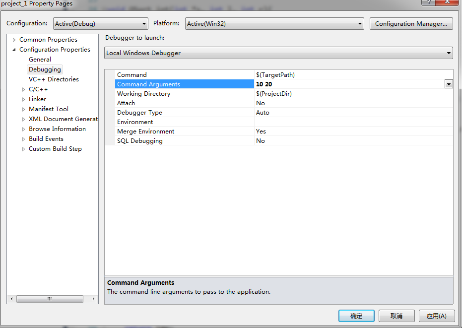

- Debug current project
- Going to the folder which is a sub-directory named “Debug” under your current project. You can find an executable file “add.exe”.
  - Open “CMD”, and use “cd” enter sub-directory “Debug”
  - Type “add 10 32”. You will get “a+b=42” on your command line.

  ```r
  add 10 32
  ```

- If you already installed “mingw32” or “mingw64” and setuped suitable library path (A good way is to install “Rtools” which includes “mingw64” in the path "D:Files_64" or "c:rtools43_64-w64-mingw32.static.posix“. You can add this path in”Environment variables“), you can follow the similar way as next subsection”On Unix OS" to build an executable file.
  - Open “CMD”, and use “cd” enter sub-directory “Debug”
    - Type “gcc add.c -o add”. If there is an error, try to type “g++ add.c -o add”

    ```r
    gcc add.c -o add
    ```

    - You can find an executable file “add.os” in the sub-directory “Debug”
    - Go back to terminal, type “./add 10 32”. You will get “a+b=42” on your command line.

    ```r
    add 10 32
    ```

  - Or open mimic terminal, such as “msys”, and use “cd” enter sub-directory “Debug”
    - Type “gcc add.c -o add”. If there is an error, try to type “g++ add.c -o add”

    ```r
    gcc add.c -o add
    ```

    - You can find an executable file “add.os” in the sub-directory “Debug”
    - Go back to terminal, type “./add 10 32”. You will get “a+b=42” on your command line.

    ```r
    ./add 10 32
    ```

### 5.2.2 On Unix type OS, such as Mac OS/Linux/Ubuntu…

- It is much simpler than Windows OS
  - Open terminal, and use “cd” enter sub-directory “Debug”
  - Type “gcc add.c -o add”. If there is an error, try to type “g++ add.c -o add”

  ```r
  gcc add.c -o add
  ```

  - You can find an executable file “add.os” in the sub-directory “Debug”
  - Go back to terminal, type “./add 10 32”. You will get “a+b=42” on your command line.

  ```r
  ./add 10 32
  ```

# 6 Learning “Debug” by yourself

## 6.1 There are three usual methods to “Debug”

- Build first,
  - See if there is any grammer error
  - Click on “build”, choose “Build Solution”
  - Or click on “build”, choose “Rebuild Solution” if your codes have no any revision
- Set “break point”
  - See if there is any unnormal value of any variable
  - It may need to set multi-breaks
  - Or set breaks in inner iteration
- Make full use of “printf()”
  - Printf out what you think it’s wrong in high probability
  - See if there is any unnormal value by “printf()”